# Assignment 3

Husayn Jessa and Aidan Bodner

16/11/2022

# Load Packages

```r
library(here)
library(dplyr)
```

```r
library(ggplot2)
library(tidyverse)
library(ggrepel)
library(ggtext)
library(showtext)
library(stringr)
library(fastDummies)
library(modelsummary)
library(lubridate)
library(gtsummary)
library(fixest)
library(quantreg)
library(binsreg) # For binscatters
library(nprobust) # Local linear regression
```

#PART 1 Diff-in-Diff

## Data and Cleaning

```r
name <- Sys.info()
name[7]
```

```
##          user
## "aidanbodner"
```

```r
assign_data <- read.csv("a3_p1_sourdough_trends.csv")
```

## Question 1a

```r
#create column new_date to change the date variable into dates
assign_data$date <- str_replace_all(assign_data$date, "T00:00:00Z", "")
assign_data$new_date <- ymd(assign_data$date)
class(assign_data$new_date)
```

```
## [1] "Date"
```

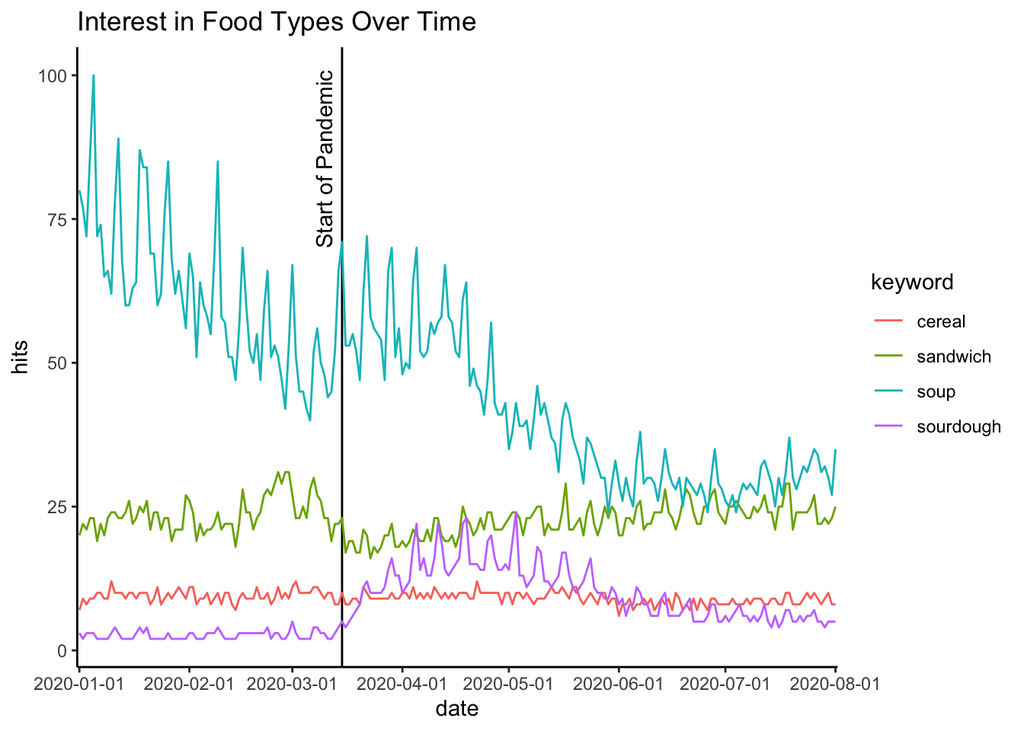

```r
hq1_line_graph <- ggplot(assign_data, aes(x = date, y = hits, colour = keyword, group = keyword)) +
                theme_classic()  + geom_vline(xintercept = assign_data$date[75], show.legend = FALSE) + annotate("text", x=assign_data$date[70], y=86, label="Start of Pandemic ", angle=90) + geom_line() +  scale_x_discrete(breaks = c("2020-01-01",
                              "2020-02-01",
                              "2020-03-01",
                              "2020-04-01",
                              "2020-05-01",
                              "2020-06-01",
                              "2020-07-01",
                              "2020-08-01")) + ggtitle("Interest in Food Types Over Time")

hq1_line_graph
```

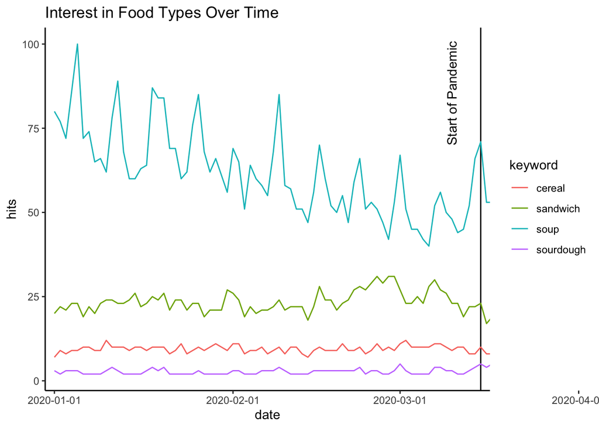

```r
# Look at plot at pre-treatment, to gauge trend lines and similarities or differences:

hq1_line_graph + coord_cartesian(xlim= c(0,76))
```

```r
#we can see before the start of the pandemic sourdough looked similar to cereal but did not look anything like soup or sandwich so considering droping thos
```

Based on the graph we created, when the pandemic started there were temporary effects on the popularity of sourdough bread. From the graph we can see that after the start of the pandemic the hits for sourdough increased to a certain point then started to decline back to pre pandemic levels. For cereal and sandwich respectively, their popularity levels remained relatively the same before and after the pandemic started. Soup was experiencing a decline in popularity before the pandemic began and then experienced a small increase in popularity when the pandemic began but soon after continued its descent in popularity. As sourdough is our variable of interest, it was interesting to see that the levels in popularity increased for a few months after the pandemic began however it appears that as people got used to living in the pandemic, they returned to their pre pandemic habits.

Sourdough bread will be considered our Treated group and thus when looking at the other foods as controls, some are more appropriate than others. When the graph was zoomed in to look at the popularity trends before the pandemic began it can be noted that the trend of sourdough bread looks most like that of cereal. They both experience low peaks and dips in their popularity trend line and have very similar locations at where these peaks and dips occur. Sourdough’s trend line and sandwich’s trend line do not look as similar, as sandwich popularity appears to have much more changes and sharper dips and peaks than that of sourdough’s. The trend line for soup is the most distinct from that of sourdoughs as it has large variation in popularity over time and it has a clear downward trend in popularity. Based on the pre-pandemic trend lines, it appears that cereal would serve as the best control group for sourdough as the two trend lines look very similar and thus without any impactful events (such as a pandemic) it could be predicted that their trend lines would look similar if extrapolated.

## Question 1B

```r
assign_data$date = as.Date(assign_data$date)

prior_trends_data <- assign_data %>% mutate(treated = ifelse(keyword == "sourdough", 1, 0),
                              interaction = ifelse(keyword == "sourdough",date,0))
prior_trends_data <- prior_trends_data %>% filter(date < "2020-03-15")

prior_trends_test<- lm(hits ~ date + interaction, data=prior_trends_data)

msummary(list("all_controls" = prior_trends_test), vcov=c(rep("robust",1)), fmt = "%#.5f",
         stars=c('*' = .1, '**' = .05, '***' = .01))
```

|  | all_controls |
| --- | --- |
| (Intercept) | 1746.06662* |
|  | (1048.47834) |
| date | −0.09369 |
|  | (0.05727) |
| interaction | −0.00158*** |
|  | (0.00009) |
| Num.Obs. | 296 |
| R2 | 0.284 |
| R2 Adj. | 0.279 |
| AIC | 2627.0 |
| BIC | 2641.7 |
| Log.Lik. | −1309.489 |
| F | 178.850 |
| RMSE | 20.19 |
| Std.Errors | Robust |

```r
prior_trends_test_droppedcontrols <- prior_trends_data %>% filter(keyword %in% c("sourdough","cereal"))

new_prior_trends_test<- lm(hits ~ date + interaction, data=prior_trends_test_droppedcontrols)

msummary(list("dropped_controls"=new_prior_trends_test), vcov=c(rep("robust",1)), fmt = "%#.5f",
         stars=c('*' = .1, '**' = .05, '***' = .01))
```

|  | dropped_controls |
| --- | --- |
| (Intercept) | −100.68840 |
|  | (66.99969) |
| date | 0.00602 |
|  | (0.00366) |
| interaction | −0.00037*** |
|  | (0.00001) |
| Num.Obs. | 148 |
| R2 | 0.937 |
| R2 Adj. | 0.936 |
| AIC | 392.9 |
| BIC | 404.9 |
| Log.Lik. | −192.462 |
| F | 1056.906 |
| RMSE | 0.89 |
| Std.Errors | Robust |

Two tests were performed to identify whether the prior trends differ between the treated and control groups. In the first prior trends test, all control groups for sourdough were included. The data was filtered to only include dates before the pandemic began to ensure only prior trends were being evaluated. In the test that included all the controls, the coefficient for the interaction term was -0.00158. This value was quite small and at first glance indicates that the all the other food items, soup, sandwich and cereal may be good controls. However, in part (a), graphically we were able to identify that cereal served as the best control for sourdough and thus the test was re-run with only cereal as the control group. When this was completed the coefficient for the interaction term got closer to 0 as it was -0.00037. This can be interpreted as cereal and sourdough having little differences between them before the pandemic began. As the coefficient got smaller, we know that cereal by itself serves as the better control as the coefficient represents little difference between the two groups. When we drop the other control variables, our standard errors decrease and our R^2 increases too, indicating a more precise estimate of the number of hits and better model fit.

One thing that was interesting and a bit concerning was that the graph made soup appear as a very bad control so it was expected that the test that included all the control groups would have a larger coefficient for the interaction term to represent how different sourdough was from all the other controls.

## Question 1c

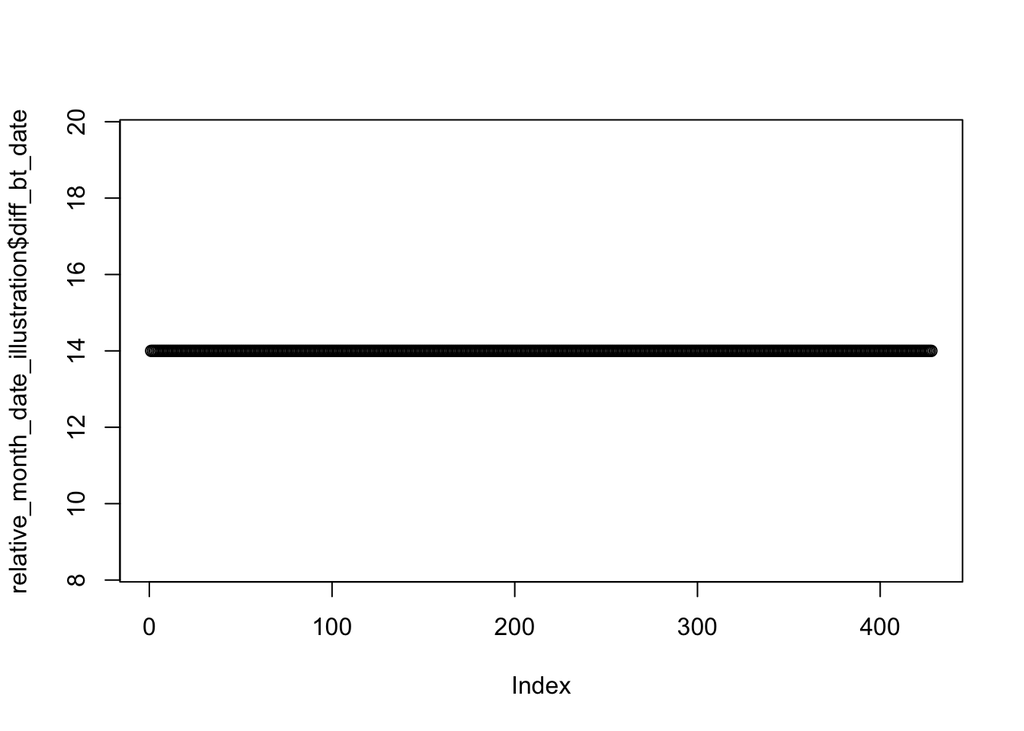

```r
# Create Treated Variable for sourdough https://www.princeton.edu/~otorres/DID101R.pdf

regdata <- assign_data %>% mutate(treated = ifelse(keyword == "sourdough", 1, 0))

# Create a dummy variable to indicate the time when the treatment started.

regdata <- regdata %>% mutate(pandemic_begun = ifelse(date >= "2020-03-15", 1, 0))

new_regdata <- regdata %>% filter(keyword %in% c("sourdough","cereal"))

new_regdata <- new_regdata %>% mutate(interaction = treated*pandemic_begun)


#create a relative_month variable by shifting the "date" variable back 15 days (so that the treatment day is the first day of the month)  and then taking the month of the resulting date
new_regdata <- new_regdata %>% mutate(relative_month = new_date - 14)
#shift date back 14 days, used new_date instead of date as date is a character while new date is the class date
# We used 14 so that the treatment day is may 1 rather than February 29


#create an "After" variable equal to 1/0 or True/False if the date is March 15 or afterwards

new_regdata <- new_regdata %>% mutate(After = ifelse(relative_month >= "2020-03-15", 1, 0 ))


#illustrate how the values of "relative_month" line up with "date" and subtract a number from "relative_month" so the last period just before treatment (Feb 16 - Mar 14)  is 0. (Also, change the Jan 1 -14 month so it's one less than the Jan 15- Feb 14 month)

relative_month_date_illustration <- new_regdata %>% select(relative_month, new_date)

#table with relative month and new date next to each other
relative_month_date_illustration <- relative_month_date_illustration %>% mutate(diff_bt_date = difftime(new_date, relative_month, units = "days"))

plot(relative_month_date_illustration$diff_bt_date)
```

```r
q_c_table <- tibble(relative_month_date_illustration)
```

## Question 1d

```r
#Use two-way fixed effects to estimate the difference-in-difference estimate of the effect of lockdown on sourdough popularity. What are your two fixed effects?

fixed_effects_model <- feols(hits ~ interaction | pandemic_begun + treated, data = new_regdata)

fixed_effects_model
```

```
## OLS estimation, Dep. Var.: hits
## Observations: 428
## Fixed-effects: pandemic_begun: 2,  treated: 2
## Standard-errors: Clustered (pandemic_begun)
##             Estimate Std. Error      t value   Pr(>|t|)
## interaction  8.10212    2.4e-13 3.379358e+13 1.8838e-14 ***
## ---
## Signif. codes:  0 '***' 0.001 '**' 0.01 '*' 0.05 '.' 0.1 ' ' 1
## RMSE: 2.81507     Adj. R2: 0.471204
##                 Within R2: 0.319024
```

```r
#the pandemic begun variable represents when the pandemic began in the date variable, treated variable represents sourdough as 1 and cereal as 2, the interaction is how pandemic beginning and being the treatment variable interact

#report and interpert results, with standard errors clustered at keyword level

msummary(fixed_effects_model, vcov= ~keyword, fmt = '%#.14f', stars=c('*' = .1, '**' = .05, '***' = .01))
```

|  | Model 1 |
| --- | --- |
| interaction | 8.10212355212361*** |
|  | (0.00000000000008) |
| Num.Obs. | 428 |
| R2 | 0.475 |
| R2 Adj. | 0.471 |
| R2 Within | 0.319 |
| R2 Within Adj. | 0.317 |
| AIC | 2104.6 |
| BIC | 2112.7 |
| RMSE | 2.82 |
| Std.Errors | by: keyword |
| FE: pandemic_begun | X |
| FE: treated | X |

#PART 3 Quantile and Nonparametric Regression

```r
here()
```

```
## [1] "/Users/aidanbodner/Documents/GitHub/HAD5744"
```

```r
load("/Users/aidanbodner/Documents/GitHub/HAD5744/Assignment 3/a3_p3_medicare.RData")
```

## Question 3a

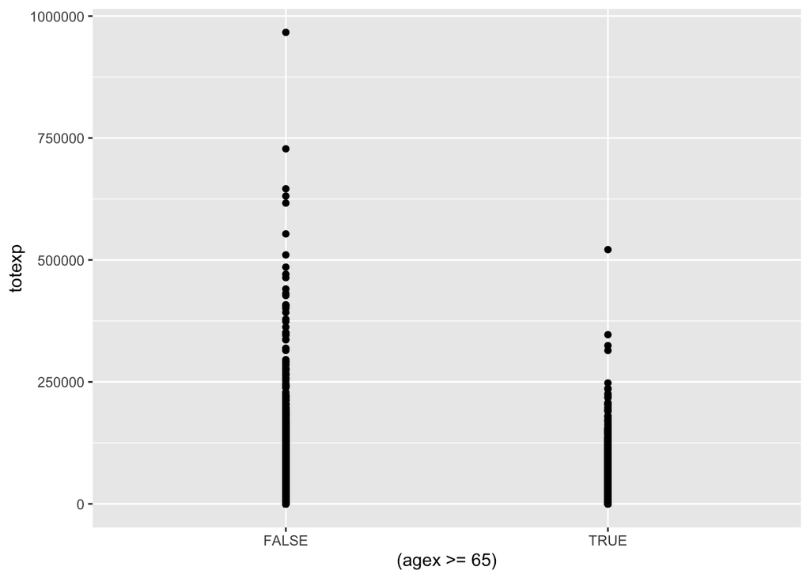

```r
# Construct Medicare coverage variable (1 = covered; 0 = not covered)
mydata <- mydata %>% mutate(medicare = ifelse(agex >= 65, 1, 0))

medicare <- mydata[mydata$medicare == 1, ]
no_medicare <- mydata[mydata$medicare == 0, ]

ggplot(mydata, aes(x = (agex >= 65), y = totexp)) + geom_point() #this also demonstrates not having medicare increases total expenditure
```

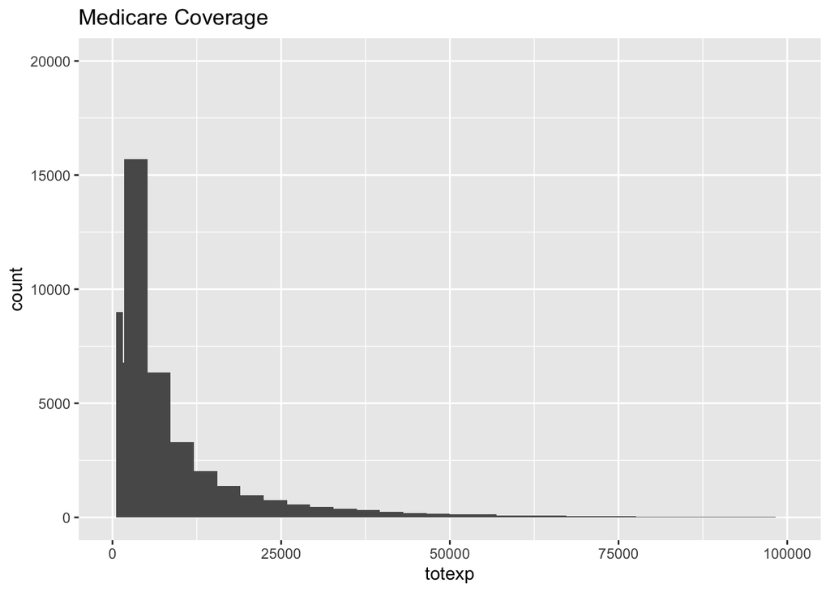

```r
# View distribution of out-of-pocket medical spending for spending after Medicare coverage
ggplot(medicare, aes(x=totexp)) + geom_histogram() + geom_histogram(bins = 100) + xlim(0, 100000) + ylim(0, 20000) + ggtitle("Medicare Coverage")
```

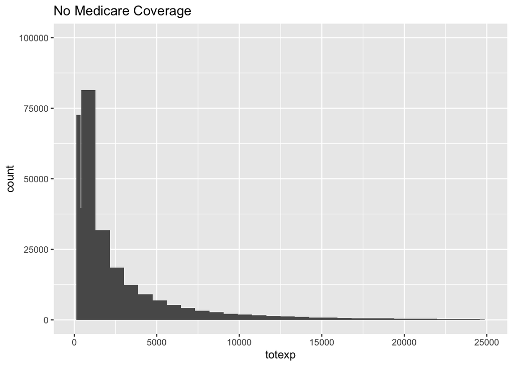

```r
# View distribution of out-of-pocket medical spending for spending before Medicare coverage
ggplot(no_medicare, aes(x=totexp)) + geom_histogram() + geom_histogram(bins = 100) + xlim(0, 25000) + ylim(0, 100000) + ggtitle("No Medicare Coverage")
```

## Question 3b

```r
naive_ols <- lm(totexp ~ medicare + sex + educyr + racex + faminc, data = mydata, weights = perwt)
msummary(list("naive_ols"=naive_ols), vcov = c(rep("robust",1)), stars=c('*' = .1, '**' = .05, '***' = .01))
```

|  | naive_ols |
| --- | --- |
| (Intercept) | 1200.685*** |
|  | (139.106) |
| medicare | 5644.332*** |
|  | (151.493) |
| sex | 696.622*** |
|  | (79.957) |
| educyr | 145.693*** |
|  | (7.819) |
| racex | −222.687*** |
|  | (32.212) |
| faminc | −0.004*** |
|  | (0.001) |
| Num.Obs. | 126780 |
| R2 | 0.038 |
| R2 Adj. | 0.038 |
| AIC | 2756068.9 |
| BIC | 2756137.2 |
| Log.Lik. | −1378027.455 |
| F | 492.793 |
| RMSE | 10571.67 |
| Std.Errors | Robust |

```r
attach(mydata)
```

The naive OLS estimate for the effect of Medicare on total expenditures is that being on Medicare increases an individuals total spending by $5644.33 (this result was significant) when all controls are held constant.This is counter-intuitive to what we would have expected as in part A the distribution of total spending made it appear that Medicare offered financial protection. One explanation for this may be that elderly individuals use more health services and thus even though medicare provides some financial protection, people older than 65 still use more health services and incur greater costs.

## Question 3c

```r
mytau <- rep(NA,20) # empty vector: quantiles
coefs <- rep(NA, 20) # empty vector: coefficients
lb <- rep(NA, 20) # empty vector: 95% LB
ub <- rep(NA, 20) # empty vector: 95% UB
for (t in 1:20) {
  mytau[t] <- t/20 # indicate which decile I am using
  print(paste0("Considering quantile ",mytau[t],sep=" "))
quantreg <- rq(totexp ~ medicare + educyr + sex + racex + faminc, data = mydata, weights = perwt,
              tau = mytau[t]) # tau ranges from 0 to 1
  coefs[t] <- quantreg$coefficients[2]
  quantsummary <- summary(quantreg, se = "iid")
  lb[t] <- coefs[t]-1.96*quantsummary$coefficients[2,2]
  ub[t] <- coefs[t]+1.96*quantsummary$coefficients[2,2]
}
```

```
## [1] "Considering quantile 0.05 "
## [1] "Considering quantile 0.1 "
## [1] "Considering quantile 0.15 "
## [1] "Considering quantile 0.2 "
## [1] "Considering quantile 0.25 "
## [1] "Considering quantile 0.3 "
## [1] "Considering quantile 0.35 "
## [1] "Considering quantile 0.4 "
## [1] "Considering quantile 0.45 "
## [1] "Considering quantile 0.5 "
## [1] "Considering quantile 0.55 "
## [1] "Considering quantile 0.6 "
## [1] "Considering quantile 0.65 "
## [1] "Considering quantile 0.7 "
## [1] "Considering quantile 0.75 "
## [1] "Considering quantile 0.8 "
## [1] "Considering quantile 0.85 "
## [1] "Considering quantile 0.9 "
## [1] "Considering quantile 0.95 "
## [1] "Considering quantile 1 "
```

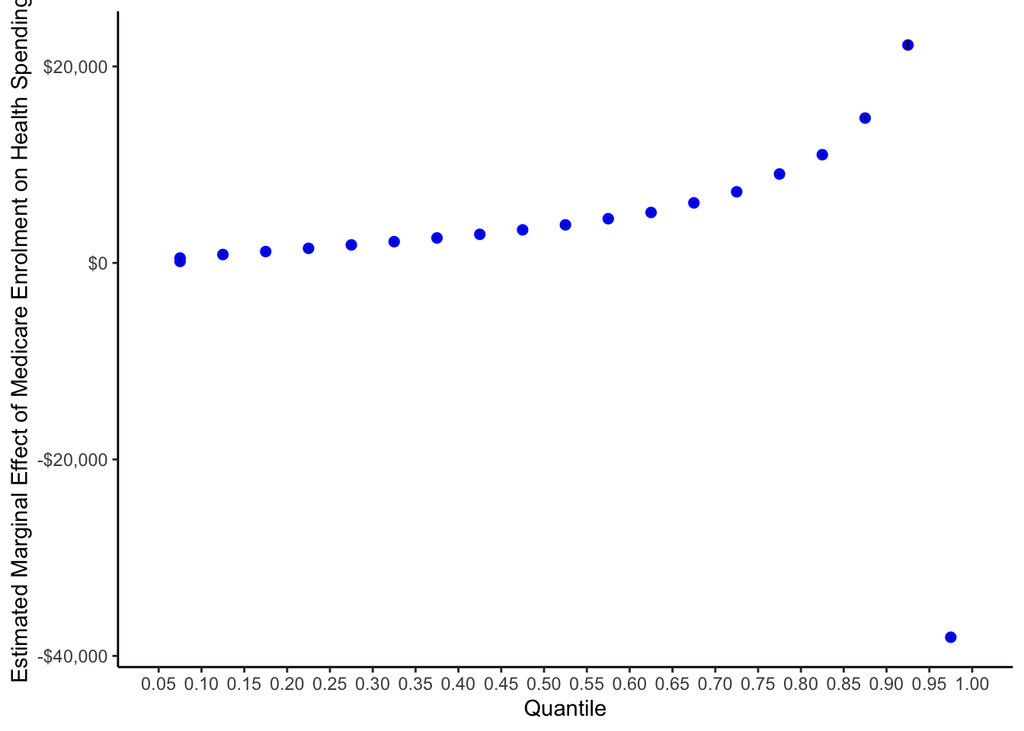

```r
plotdata <- read.csv("Dataframe_for_Question3c")

# Look at distribution of coefficients
plotdata %>%ggplot(aes(x=mytau)) +
  geom_point(aes(y=coefs),size=2,color='blue') +
  geom_errorbar(aes(ymin = lb, ymax = ub),width=0.03) +
  scale_y_continuous(labels=scales::dollar_format()) +
  scale_x_binned(n.breaks = 20, limits = c(0.05, 1.00)) +
  theme_classic() + labs(x="Quantile", y="Estimated Marginal Effect of Medicare Enrolment on Health Spending")
```

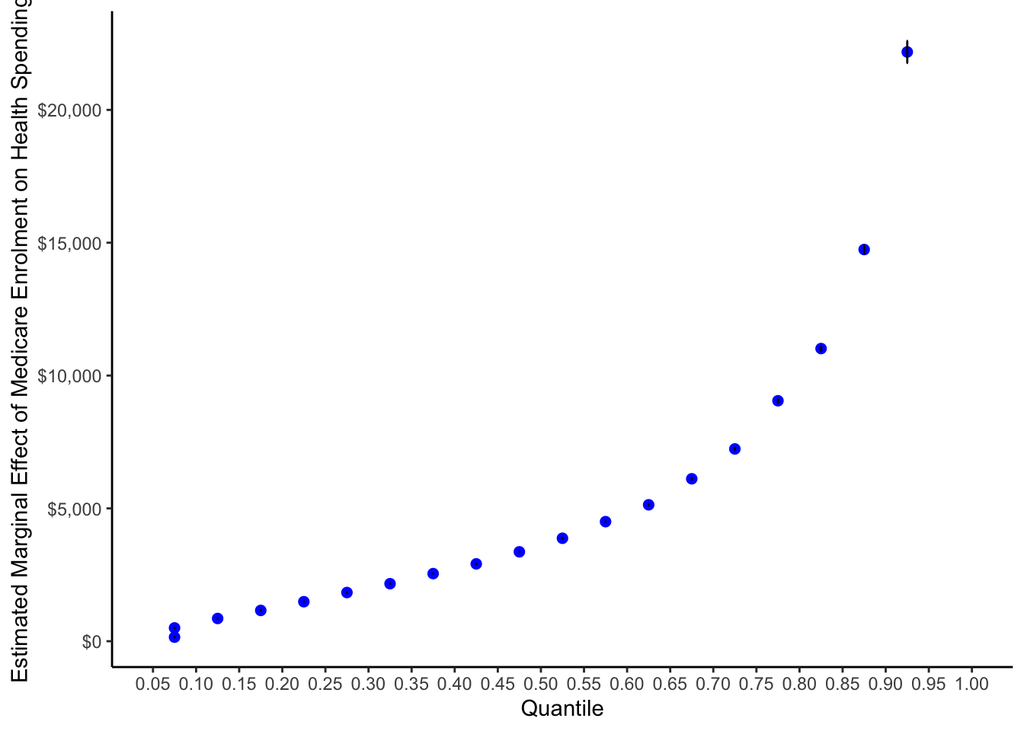

```r
# Look to see if the dropping people who contribute negative costs makes the plot more readable
plotdata %>% filter(mytau < 1) %>% ggplot(aes(x=mytau)) +
  geom_point(aes(y=coefs),size=2,color='blue') +
  geom_errorbar(aes(ymin = lb, ymax = ub),width=0.03) +
  scale_y_continuous(labels=scales::dollar_format()) +
  scale_x_binned(n.breaks = 20, limits = c(0.05, 1.00)) +
  theme_classic() + labs(x="Quantile", y="Estimated Marginal Effect of Medicare Enrolment on Health Spending")
```

```r
# The plot is not that much more readable and even takes away from the story of medicare enrolment on health spending as negative spending is still an important component to understanding what medicare does to health spending.
```

We can see from the plots of spending quantiles that as the quantile increases, so does the marginal effect of medicare on health expenditure. This may be due to individuals in higher quantiles of health spending already having high total health expenditures and as a result medicare has less of an effect on reducing the costs for these individuals. Also, the cumulative health spending in these groups may already be high so after receiving medicare their expenditure continues to be high or they access more services due to now having medicare. An interesting thing to note about the trend is that it occurs up until the twentieth quantile, when medicare enrollment causes negative marginal effect on health spending. This may be because this quantile is composed of superutilizers who cost the system the most and therefore may activate a more substantial tier of medicare that covers more expenses for this group. The result in the twentieth quantile may also be an outlier and a result of improper data however we decided not to drop it as it risks us not telling the full story. We can also see from our plot that our coefficients have non-overlaping confidence intervals indicating that the level changes between each quantile is significantly different from one another.

## Question 3d

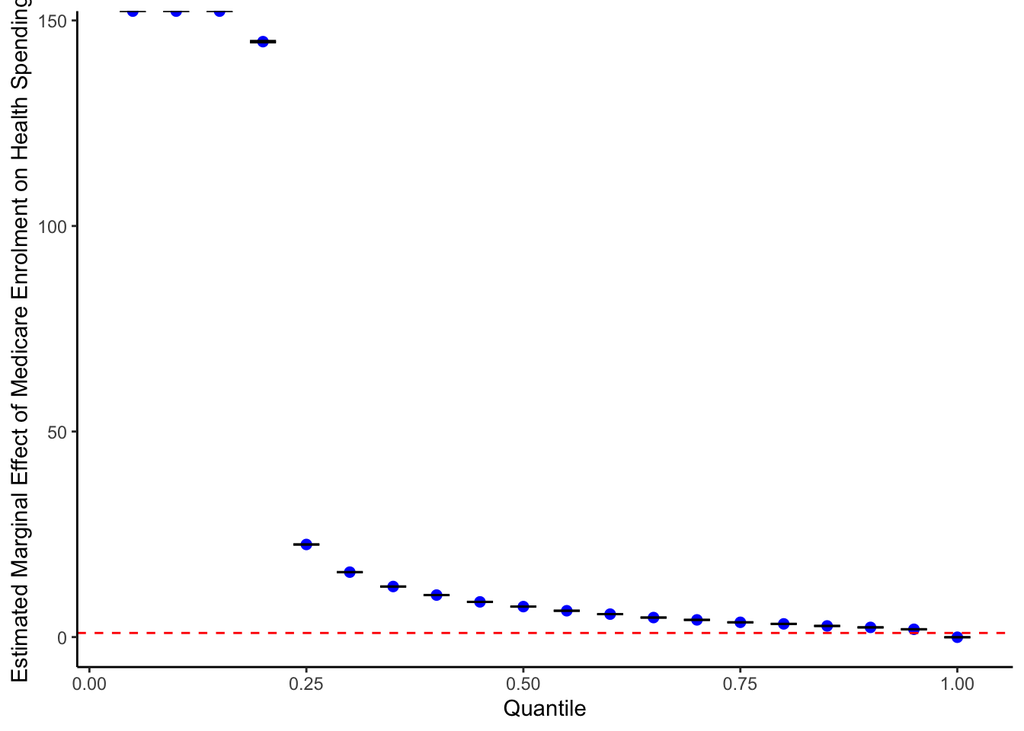

```r
# Construct a figure of coefficients across distribution
myquants <- quantile(mydata$totexp,probs=c(0.05, 0.1, 0.15, 0.2, 0.25, 0.3, 0.35, 0.4, 0.45, 0.5, 0.55, 0.6, 0.65, 0.7, 0.75,
            0.8, 0.85, 0.9, 0.95, 1), na.rm=TRUE)
plotdata %>% mutate(coefs = coefs / myquants,
                    lb = lb / myquants,
                    ub = ub / myquants) %>%
  ggplot(aes(x=mytau))+
  geom_point(aes(y=coefs),size=2,color='blue') +
  geom_errorbar(aes(ymin = lb, ymax = ub),width=0.03) +
  geom_hline(yintercept=1,color='red',linetype='dashed') +
  theme_classic() +
  labs(x="Quantile", y="Estimated Marginal Effect of Medicare Enrolment on Health Spending")
```

This scaling changes the interpretation as it allows us to determine where the largest changes in health spending due to medicare occur within in each quantile. We can see that in the first 3 quantiles, the marginal effect of medicare on health spending is infinite as the quantile of spending in the first 3 groups is 0. As we move across the quantiles we can see that the marginal effect on health spending decreases as the quantiles get larger. This plot shows that the lower spending quantiles are affected largely by having medicare as it greatly increases their total expenditure. In the 4th quantile, medicares effect is approximately 140x the spending within that quantile. As the quantiles increase towards the 19th quantile, medicare has less of an effect on how much is being spent on healthcare as they approach the dashed line which represent about 1x the amount spent in the quantile. We can see that for individuals in the 20th quantile, medicare almost has no influence in the amount they spend on health care which can be hypothesized to be a result of medicare saving this group money where they would have already spent it or that they were already super spenders who will spend regardless of having medicare or not.

This plot also shows us that the effect of medicare largely drops when moving from the 4th quantile to the 5th quantile as the effect of medicare on the spending in that quantile goes from approximately 140x the spending in that quantile to about 25x the spending in the next quantile. The effects of medicare drops further from quantile to quantile as these groups already have high expenditures on health care. Their expenditures thus may not be influenced as much by obtaining medicare. It also suggests that something may be occurring within the lower quantile groups such as prior to medicare these groups resisted interacting with the healthcare system due to fear of taking on the cost of care.

## Question 3e

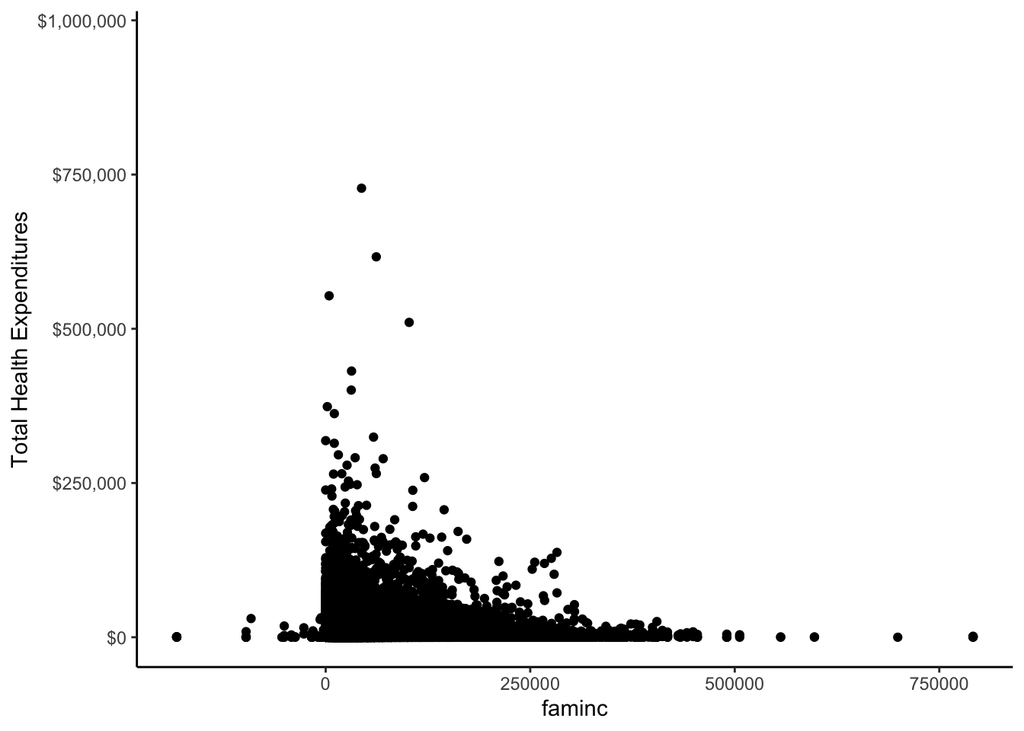

```r
# Check this site for helpful coding tips for nonparametric techniques: https://nppackages.github.io/
# Binscatter: relationship between income and spending
mydata%>% ggplot(aes(x=faminc ,y=totexp)) +
  geom_point() +
  theme_classic() +
  scale_y_continuous(labels=scales::dollar_format()) +
  labs(x="faminc",y="Total Health Expenditures") # This is hard to interpret
```

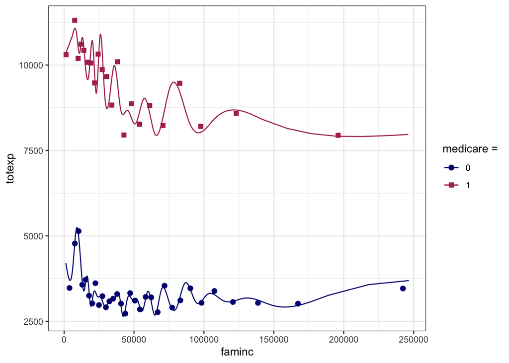

```
## Call: binsreg
##
## Binscatter Plot
## Bin selection method (binsmethod)  =  IMSE direct plug-in
## Placement (binspos)                =  Quantile-spaced
## Derivative (deriv)                 =  0
##
## Group (by)                         =  0
## Sample size (n)                    =  119312
## # of distinct values (Ndist)       =  22266
## # of clusters (Nclust)             =  NA
## dots, degree (p)                   =  0
## dots, smooth (s)                   =  0
## # of bins (nbins)                  =  33
##
## Group (by)                         =  1
## Sample size (n)                    =  14419
## # of distinct values (Ndist)       =  7664
## # of clusters (Nclust)             =  NA
## dots, degree (p)                   =  0
## dots, smooth (s)                   =  0
## # of bins (nbins)                  =  22
```

```r
# Omit missing observations on educyr
mydata <- mydata[!is.na(mydata$educyr), ]

# Let's bin the data more
binsreg(y=totexp,x=faminc,by=medicare,
        w= ~ sex + educyr + factor(racex),
        weights = perwt,
        data=mydata,
        plotxrange = c(0, 250000),
        line=c(3,3)) # If we want any confidence intervals on points
```

We can see at the lower end of family income (approaching zero) that the differences in total expenditure are greatest between people who receive and do not receive medicare. This suggests that lower income individuals require more healthcare services, so being enrolled in medicare can be very beneficial in ensuring access to care. Between the two curves it does appear that the difference in expenditure between the medicare group and non-medicare group is related to family income. As family income increases for both groups they each have a decrease in expenditure and this indicates that higher family incomes lead to healthier family members and less expenditure on health care. The difference between the two curves begins to converge then level off as family income increases. This may mean that for the non-medicare group, being very wealthy leads to higher spending on medicare because the cost of healthcare is not something these families consider. This also may mean that being wealthy and being on medicare means that you are healthier in old age and thus require less health services or already spend a certain amount on health services that doesn’t change when becoming eligible for medicare.

# Question 3f

The results from (e) imply that the use of nonparametric regression could be a valid approach when working with this data. From (e), we could identify the trends between the total expenditure on health and how that related to family income distribution. We could also see that the bins created are spread out across the range of family income and the nonparametric line captures the shape between these bins. We were also able to identify how being old enough for medicare effects the trends between those two variables too. The shape of the relationship appears to provide a clear story about how income distribution influences total expenditure for both the medicare and non-medicare group and as a result it appears to provide valuable insight into the data. A framework that may be used to recover a nonparametric conditional density estimator of the effect of Medicare coverage over the income distribution is through using the kernel based density estimator. For this to be a valid framework, the kernel function must be symmetrical. The symmetric property of kernel functions allow for the maximum value of the function to be in the middle of the curve created by the function. Second the area under the curve of the kernel function must also equal 1. Finally the value of the kernel function can’t be negative. To ensure the data fits appropriately with the kernel function, an optimal bandwidth value is also required. A low value for bandwidth estimates the density value with lots of variance while a high bandwidth value creates large amount of bias. The choice of kernel size also is important as too large of a value leads to boundaries between classes being less distinct but allows for a reduction of the noise effect on classification while a too small kernel size has the opposite effects. If all these conditions are met then it is possible to obtain a conditional density estimator for our data using this method.

https://medium.com/analytics-vidhya/kernel-density-estimation-kernel-construction-and-bandwidth-optimization-using-maximum-b1dfce127073 <- information on kernel density estimation was obtained here

# Question 3g

Medicare protects low-income people 65 years or older from the risk of high out-of-pocket health expenditures as well as eliminating a financial barrier in accessing care. We can see this in (e), where there is a substantial difference in total expenditure, this is primarily among low-income individuals. In (e) we can see that individuals on medicare have larger amounts of total expenditure and this speaks to why medicare is necessary for these groups. We can also see similar findings in (d) where we could see that having medicare greatly increased the spending of individuals in the lowest health spending as they now had a means to accessing health care through medicare insurance. We know that aging leads to increased health costs and that low income people have worse health outcomes than higher income people. As a result, Medicare is useful to protect these individuals from catastrophic risk.

Potential open back doors: As we see large differences in quantiles on total expenditure in (d), a potential open back door that may be influencing this result is health status. Regardless of medicare coverage, health status will increase health expenditure. Another open back door that may be influencing the results is that, some people may have more than one insurance plan that covers the costs of the health spending and as such medicare may not be the only insurance plan members in our data set have. Thus the distributional effect of medicare as a form of risk protection may not be the true effect if the role of other insurance plans is not closed.

Policy Implications: Our findings point to the need for policymakers to give greater public insurance coverage to low-income people as our findings indicate that this group contributes to substantial health expenditure when covered by medicare compared to when not covered by medicare. By providing health care to these groups at an earlier stage it may mitigate the increased level of spending these groups have when they receive medicare after 65.

```r
print("=============================Works Cited=============================")
```

```
## [1] "=============================Works Cited============================="
```

```r
loadedNamespaces() %>%
  map(citation) %>%
print(style = "text") # Adds citations for each package to end of .rmd file
```

[output not shown]

[output cut: 593 more lines]

[output not shown]

```r
knitr::write_bib(file = 'packages.bib') # Constructs a citation file for all packages used in this file
```